# Guia introducción al análisis multivariado

Métodos de análisis no paramétricos

Dr. José A. Gallardo.

Profesor adjunto de la Pontificia Universidad Católica de Valparaíso  
jose.gallardo@pucv.cl

May 23, 2021

#### Objetivos de aprendizaje

Calcular matrices de distancia euclideana y no euclideana usando **software R**.

#### Conceptos importantes

La estadística multivariante o multivariada es una rama de las estadísticas que abarca la observación y el análisis simultáneos de más de una variable respuesta. La aplicación de la estadística multivariante es llamada [análisis multivariante](https://es.wikipedia.org/wiki/Estad%C3%ADstica_multivariante).

Los análisis multivariantes son muy utilizados en Ciencias del Mar y Oceanografía como herramienta para realizar análisis exploratorio de datos y detectar variables latentes.

**Análisis de agrupamiento o “cluster”**  
Los análisis de agrupamiento o clustering en ingles tiene como objetivo agrupar datos (muestras) por similitud, en grupos o conjuntos de manera que los miembros del mismo grupo tengan características similares [Wiki.](https://es.wikipedia.org/wiki/An%C3%A1lisis_de_grupos)

**Análisis de componentes principales**  
Los análisis de componentes principales (en español ACP, en inglés, PCA) son una técnica utilizada para describir un conjunto de datos en términos de nuevas variables («componentes») no correlacionadas. Los componentes se ordenan por la cantidad de varianza original que describen, por lo que la técnica es útil para reducir la dimensionalidad de un conjunto de datos [Wiki.](https://es.wikipedia.org/wiki/An%C3%A1lisis_de_componentes_principales).

**Matriz de distancia o similaridad**  
Subyacente a muchos de los análisis multivariantes está el uso de matrices de distancia o similaridad por lo que su calculo y adecuada interpretación es fundamental previo a la realización de los análisis multivariantes.

Una matriz de distancias es una matriz cuyos elementos representan las distancias entre los puntos, tomados por pares, de un conjunto. Se trata, por lo tanto, de una matriz simétrica de tamaño NxN.

**Matriz de distancia euclideana**  
La distancia euclidiana, es la distancia entre dos puntos de un espacio euclídeo, la cual se deduce a partir del teorema de Pitágoras [Wiki.](https://es.wikipedia.org/wiki/Distancia_euclidiana)

#### Software.

Esta es la versión de R que se usó para crear esta guía.

```r
R.version.string
```

```
## [1] "R version 3.6.1 (2019-07-05)"
```

#### Librerías.

**{stats}**  
This package contains functions for statistical calculations and random number generation.

**{readxl}**  
Read Excel Files.

**{dplyr}**  
Librería para manipular datos.

**{vegan}** Librería que implementa métodos de ordenación y diversidad ecológica.

#### Comandos para realizar los análisis.

**read_excel()**  
Importa datos a R desde archivos excel.

**select** Selecciona variables desde un data.frame o una tibble.

**%>%** El operador pipe sirve para concatenar tareas o funciones.

**mutate()** Crea nuevas variables a partir de variables originales de un data.frame o una tibble.

**t()** Dada una matriz x, t() entrega la transpuesta x.

**dist()** Calcula diferentes matrices de distancia entre las filas de un conjunto de datos.

**vegdist** Calcula diferentes medidas de distancia o similaridad (usualmente para datos de ecología) entre las filas de un conjunto de datos.

#### EJERCICIOS

Realice los ejercicios de forma colaborativa con uno o dos compañeros.

Elabore un archivo Rmarkdown o file con extensión **.Rmd** en Rstudio o Rstudio.cloud y configurelo para exportar el resultado como un documento dinámico **pdf**.

En el primer bloque de códigos o **chunk** configure los comandos de la siguiente manera *knitr::opts_chunk$set(echo = TRUE)* y habilite las librerías **stats**, **readxl**, **dplyr**, **vegan^**, **psych** usando la función library().

A partir del set de datos **bioenv.xlsx** disponibles en el libro MULTIVARIATE ANALYSIS OF ECOLOGICAL DATA de los autores [Michael Greenacre and Raul Primicerio](https://www.fbbva.es/microsite/multivariate-statistics/) realice los siguientes ejercicios

**Ejercicio 1.** Importar y explorar

1. Importe la hoja 1 set de datos **bioenv.xlsx** usando la función *read_excel()* de la librería *readxl*. No olvide usar el argumento *Sheet=1*. Explore el set de datos usando las funciones *summary()*. Compruebe que todas las variables numéricas están expresadas como número y que las variables Sitio y Sediment sean factores. Caso contrario realice los cambios correspondientes con las funciones **as.numeric()** y **as.factor()**.

```r
bioenv <- read_excel("bioenv.xlsx", sheet = 1)
summary(bioenv)
```

```
##     Sitio                 a               b                c
##  Length:30          Min.   : 0.00   Min.   : 0.000   Min.   : 0.0
##  Class :character   1st Qu.: 2.00   1st Qu.: 0.500   1st Qu.: 0.0
##  Mode  :character   Median :12.00   Median : 6.500   Median : 8.5
##                     Mean   :13.47   Mean   : 8.733   Mean   : 8.4
##                     3rd Qu.:23.25   3rd Qu.:11.750   3rd Qu.:13.0
##                     Max.   :42.00   Max.   :37.000   Max.   :33.0
##        d               e              Depth          Pollution
##  Min.   : 0.00   Min.   : 0.000   Min.   : 51.00   Min.   : 1.900
##  1st Qu.: 7.25   1st Qu.: 0.000   1st Qu.: 61.00   1st Qu.: 2.800
##  Median :10.00   Median : 1.500   Median : 73.50   Median : 4.300
##  Mean   :10.90   Mean   : 2.967   Mean   : 74.43   Mean   : 4.517
##  3rd Qu.:15.75   3rd Qu.: 6.000   3rd Qu.: 84.75   3rd Qu.: 5.550
##  Max.   :25.00   Max.   :17.000   Max.   :100.00   Max.   :10.000
##   Temperature      Sediment
##  Min.   :2.500   Length:30
##  1st Qu.:2.900   Class :character
##  Median :3.000   Mode  :character
##  Mean   :3.057
##  3rd Qu.:3.300
##  Max.   :3.600
```

```r
bioenv$Sitio <- as.factor(bioenv$Sitio)
bioenv$Sediment <- as.factor(bioenv$Sediment)
str(bioenv)
```

```
## tibble [30 × 10] (S3: tbl_df/tbl/data.frame)
##  $ Sitio      : Factor w/ 30 levels "s1","s10","s11",..: 1 12 23 25 26 27 28 29 30 2 ...
##  $ a          : num [1:30] 0 26 0 0 13 31 9 2 17 0 ...
##  $ b          : num [1:30] 2 4 10 0 5 21 6 0 7 5 ...
##  $ c          : num [1:30] 9 13 9 15 3 13 0 0 10 26 ...
##  $ d          : num [1:30] 14 11 8 3 10 16 11 0 14 9 ...
##  $ e          : num [1:30] 2 0 0 0 7 5 2 1 6 0 ...
##  $ Depth      : num [1:30] 72 75 59 64 61 94 53 61 68 69 ...
##  $ Pollution  : num [1:30] 4.8 2.8 5.4 8.2 3.9 2.6 4.6 5.1 3.9 10 ...
##  $ Temperature: num [1:30] 3.5 2.5 2.7 2.9 3.1 3.5 2.9 3.3 3.4 3 ...
##  $ Sediment   : Factor w/ 3 levels "C","G","S": 3 1 1 3 1 2 3 1 1 3 ...
```

2. Elabore una gráfica de correlaciones de las variables Depth, Pollution y Temperature usando la función **pairs.panels()**.

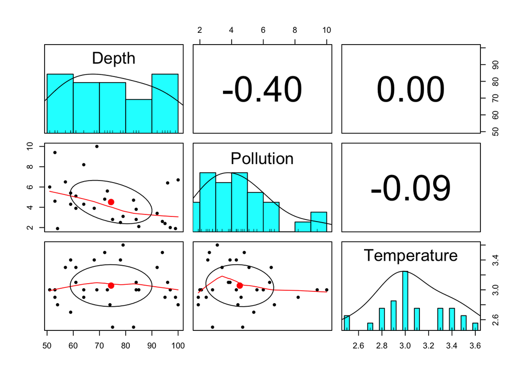

```r
pairs.panels(bioenv[7:9])
```

**Ejercicio 2.** Matriz distancia euclideana

1. Para las tres variables cuantitativas continuas Depth, Pollution y Temperature elabore 3 variables derivadas D1, P1 y T1 con su *valor estandarizado* como la diferencia de cada valor por la media **mean()** y dividiendo por la desviasión estandar **sd()**. Use la función **mutate()** de la librería **dplyr**

```r
# Crea nuevas variables
val_estandarizado <- bioenv %>%
 select(Sitio, Depth, Pollution, Temperature) %>%
 mutate(
  D1 = (Depth - mean(Depth)) / sd(Depth),
  P1 = (Pollution - mean(Pollution)) / sd(Pollution),
  T1 = (Temperature - mean(Temperature)) / sd(Temperature))
```

2. Elabore una gráfica de correlaciones de las variables estandarizadas usando la función **pairs.panels()** y compare con las correlaciones estimadas en el ejercicio **1b** que calcula la correlación con la variable original.

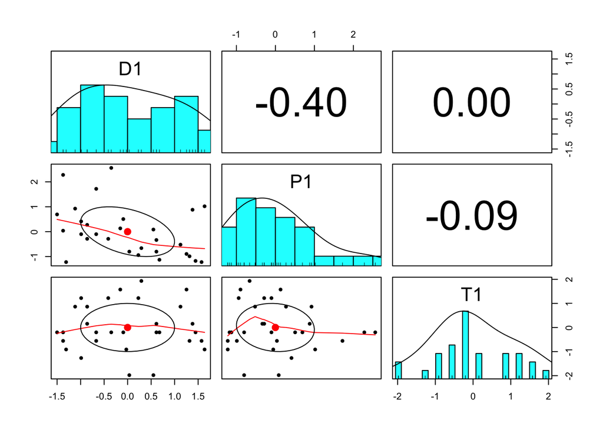

```r
pairs.panels(val_estandarizado[5:7])
```

c) Calcule la matriz de distancia euclideana estandarizada a partir de los datos D1, P1 y T1. Use la función **dist()**.

```r
dist_euclidea <- dist(val_estandarizado[5:7])
class(dist_euclidea)
```

```
## [1] "dist"
```

```r
# extracto de matriz de distancia
dist_euclidea <- as.matrix(dist_euclidea)
class(dist_euclidea)
```

```
## [1] "matrix"
```

```r
dist_euclidea[c(1:4),c(1:4)]
```

```
##          1        2        3        4
## 1 0.000000 3.681420 2.977153 2.708405
## 2 3.681420 0.000000 1.740695 2.979801
## 3 2.977153 1.740695 0.000000 1.522575
## 4 2.708405 2.979801 1.522575 0.000000
```

**Ejercicio 3.** Matriz de similaridad Bray-Curtis

1. Elabore una matriz de correlaciones no paramétrica de spearman **cor()** para los sitios s1 a s7 usando la información de abundancia de especies (a,b,c,d y e).

Sugerencia: Transponga el set de datos **bioenv** solo para las columnas ([2:6]). Si desea incluya el nombre de las filas y las columna a esta nueva matriz.

```r
t_bioenv <- t(bioenv[2:6])
colnames(t_bioenv) <- c("s1",   "s2",   "s3",   "s4",   "s5",   "s6",   "s7",   "s8",   "s9",   "s10",  "s11",  "s12",  "s13",  "s14",  "s15",  "s16",  "s17",  "s18",  "s19",  "s20",  "s21",  "s22",  "s23",  "s24",  "s25",  "s26",  "s27",  "s28",  "s29",  "s30")
rownames(t_bioenv) <- c("a","b","c","d","e")
res <- cor(t_bioenv, method = "spearman")
round(res[c(1:7),c(1:7)], 2)
```

```
##       s1    s2    s3    s4    s5    s6    s7
## s1  1.00 -0.15  0.39  0.80 -0.36 -0.46  0.05
## s2 -0.15  1.00 -0.10  0.34  0.30  0.60  0.20
## s3  0.39 -0.10  1.00  0.34 -0.72  0.10 -0.21
## s4  0.80  0.34  0.34  1.00 -0.45 -0.34 -0.22
## s5 -0.36  0.30 -0.72 -0.45  1.00  0.50  0.80
## s6 -0.46  0.60  0.10 -0.34  0.50  1.00  0.60
## s7  0.05  0.20 -0.21 -0.22  0.80  0.60  1.00
```

2. Calcule el índice de disimilaridad de Bray-Curtis usando la función **vegdist()** de la librería **vegan**.

Exprese el índice como porcentaje y compare con la correlación estimada anteriormente.

Sugerencia: imprima disimilaridad de los primeros 7 sitios y redondee a 1 decimal.

```r
Bray_curtis <- vegdist(bioenv[2:6], method="bray", binary=FALSE, diag=FALSE, upper=FALSE, na.rm = FALSE)*100
Bray_curtis <- as.matrix(Bray_curtis)
class(Bray_curtis)
```

```
## [1] "matrix"
```

```r
round(Bray_curtis[c(1:7),c(1:7)], 1)
```

```
##      1    2    3    4    5    6    7
## 1  0.0 45.7 29.6 46.7 47.7 52.2 45.5
## 2 45.7  0.0 48.1 55.6 34.8 22.9 41.5
## 3 29.6 48.1  0.0 46.7 50.8 52.2 49.1
## 4 46.7 55.6 46.7  0.0 78.6 69.2 87.0
## 5 47.7 34.8 50.8 78.6  0.0 41.9 21.2
## 6 52.2 22.9 52.2 69.2 41.9  0.0 50.9
## 7 45.5 41.5 49.1 87.0 21.2 50.9  0.0
```